# Laboratory 1

Random variables and Monte Carlo simulation

N Torelli G Di Credico V Gioia gioia.vincenzo@spes.uniud.it Office hour: Friday, 16.00 - 17.00

14/10/2022

# R Markdown

R Markdown is a powerful tool to create reports, by integrating text, formulas, R code, plots, links and so on.

Getting start:

- create a R Markdown file (File, New File)
- choose the title, the author/authors and the selected output
- the (default) header includes what you choose on the previous step
- we can add subtitle, fontsize and several options related to the outputs (not considered here)

For a better rendering, I would suggest to introduce the option fig.align = ‘center’ in the options of knitr function.

The compilation is done by clicking on the knit button (there you can choose between html or pdf, despite your initial choice).

In moodle (Lab1 folder) you will find some materials on the basic use of R Markdown, but the web is a great mine of information.

Remember that you can mask the code by writing echo=FALSE (and you can avoid the evaluation by using eval = FALSE).

We will introduce R Markdown workflow by means of some exercises of the random variables. (note about setting the seed if you fix at the beginning of the document, you cannot specify everytime, since I think you will obtain the same results. But if you do not think fix at the beginning, or you fix in the middle of Rmd file, you can find some differences)

# Working with random variables

## Gamma distribution

Let $X$ distributed according to a gamma distribution with shape parameter $\alpha$ and rate parameter $\theta$. The probability density function (pdf) of $X\sim Gamma(\alpha, \theta)$ is
$$f_X(x)= \frac{\theta^{\alpha}}{\Gamma(\alpha)} x^{\alpha-1}e^{-\theta x}, \quad \alpha, \, \theta > 0, \quad x>0$$
There exists an equivalent parametrisation in terms of shape and scale parameter ($\sigma = 1/\theta$), so
$$f_X(x)= \frac{1}{\sigma^{\alpha}\Gamma(\alpha)} x^{\alpha-1}e^{- \frac{x}{\sigma}}, \quad \alpha, \, \sigma > 0, \quad x>0$$
In R we can work with the gamma distribution by using r,d,p,q followed by gamma, depending on whether we are interested in random generation, pdf, cumulative distribution function (cdf) or quantile. A look on the R help is helpful to analyse the functions that you are using (you can see how to call a function, the arguments need to be passed, the details and the returning values of a function).

### Exercise

Consider a gamma distribution with rate parameter $\theta = 2$ and shape parameter $\alpha=2$

- Plot the probability density function and the cumulative distribution function (vary the shape or the rate parameter)
- Compute the probability $P(X<3)$, and obtain $P(X>3)$
- Compute the quantiles of order 0.25 and 0.75; identify such points in the cumulative distribution function and the quantile function
- Generate a random sample of size $n=10000$, compare the histogram with the pdf
- Compare the sample mean and variance with ${\rm E}[X]= \frac{\alpha}{\theta}$ and ${\rm V}[X]= \frac{\alpha}{\theta^2}$, respectively

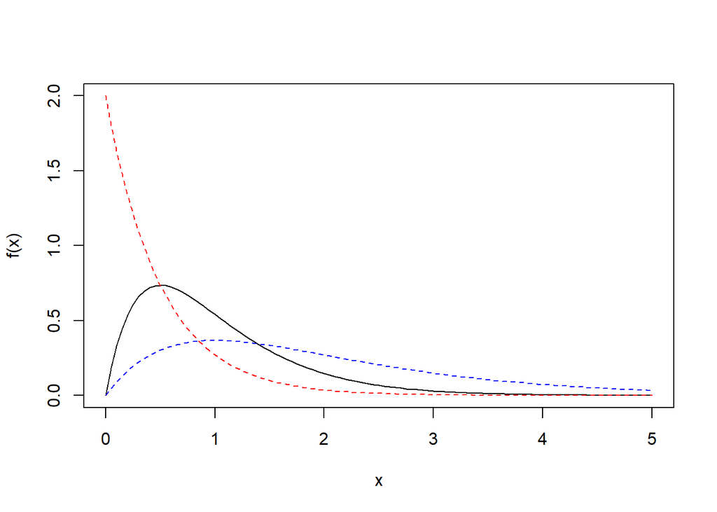

```r
alpha <- 2  # shape
theta <- 2 # rate

# Plot the pdf
plot(function(x) dgamma(x, shape = alpha, rate = theta), xlim = c(0, 5), ylab = "f(x)", ylim=c(0,2))
curve(dgamma(x, shape = 1, rate = theta), col = "red", lty = "dashed", add = TRUE)
curve(dgamma(x, shape = alpha, rate = 1), col = "blue", lty = "dashed", add = TRUE)
```

The following plot is related to the cdf

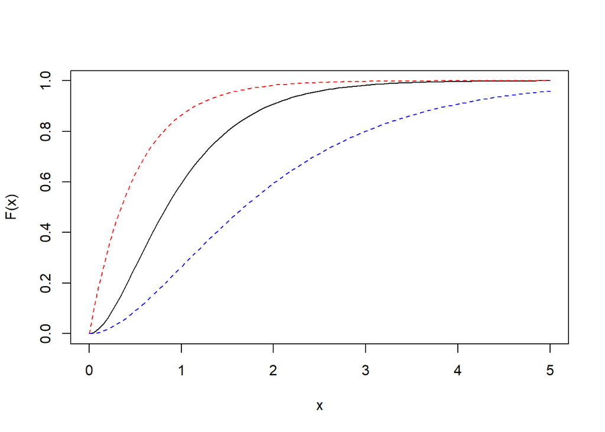

```r
# Plot the cdf
plot(function(x) pgamma(x, shape = alpha, rate = theta), xlim = c(0, 5), ylab = "F(x)")
curve(pgamma(x, shape = 1, rate = theta), col = "red", lty = "dashed", add = TRUE)
curve(pgamma(x, shape = alpha, rate = 1), col = "blue", lty = "dashed", add = TRUE)
```

Now we are interested in computing $P(X<3)$ and $P(X>3)$. Remember that they corresponds to
$$P(X<3) = F_X(3), \quad \quad P(X>3)=1-F_X(3)$$

```r
# P(X<3)
pgamma(3, shape = alpha, rate = theta)
```

```
## [1] 0.9826487
```

```r
# P(X>3)
pgamma(3, shape = alpha, rate = theta, lower.tail = FALSE)
```

```
## [1] 0.01735127
```

```r
#or 1 -  pgamma(3, shape=alpha, rate=lambda)
```

Here, we compute the quantile of order 0.25 and 0.75. Remember, the quantile of order $q \in (0,1)$, $x_q$ is stated as

$$F_X(x_q)=P(X \leq x_q)=q$$
The quantile function is simply (in the continuous case) the inverse of the cdf
$$Q(q) = F^{-1}_X(x)$$

```r
# 25th percentile
q025 <- qgamma(0.25, shape = alpha, rate = theta)
q025
```

```
## [1] 0.4806394
```

```r
# 75th percentile
q075 <- qgamma(0.75, shape = alpha, rate = theta)
q075
```

```
## [1] 1.346317
```

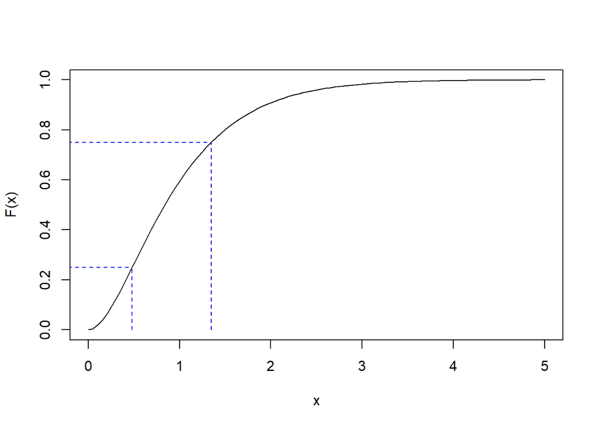

```r
# cdf and quantiles
plot(function(x) pgamma(x, shape = alpha, rate = theta), xlim = c(0, 5), ylab=" F(x) ")
segments(q025, 0, q025, pgamma(q025, shape = alpha, rate = theta), col = "blue", lty = "dashed")
segments(-0.3, pgamma(q025, shape = alpha, rate = theta), q025, pgamma(q025, shape = alpha, rate = theta),  col = "blue", lty = "dashed")

segments(q075, 0, q075, pgamma(q075, shape = alpha, rate = theta), col = "blue", lty = "dashed")
segments(-0.3, pgamma(q075, shape = alpha, rate = theta), q075, pgamma(q075, shape = alpha, rate = theta),  col = "blue", lty = "dashed")
```

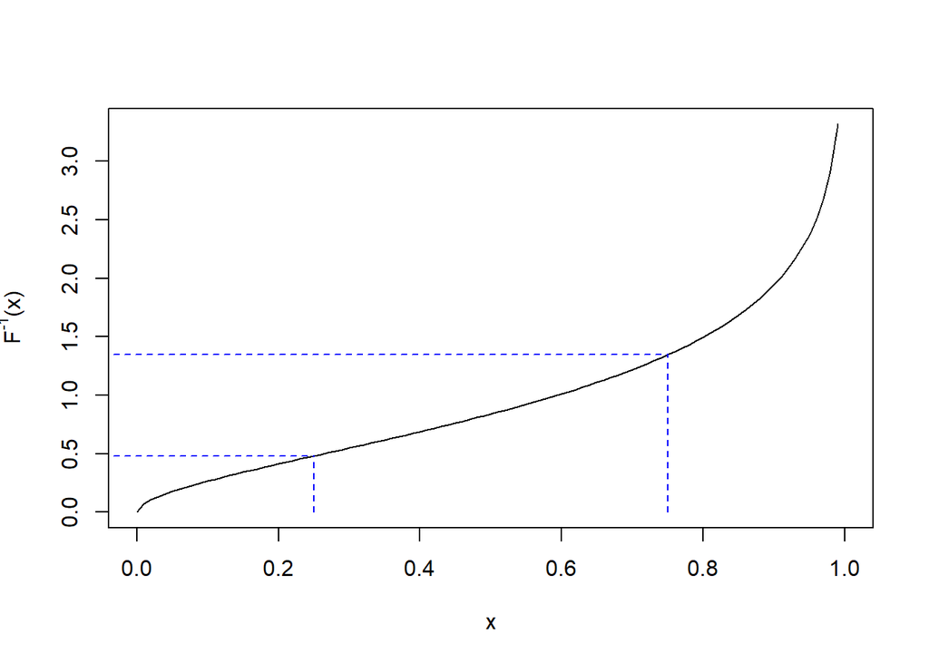

```r
# quantile function and quantiles
plot(function(x) qgamma(x, shape = alpha, rate = theta), ylab=expression(paste("F"^"-1","(x)")))
segments(-0.3, q025,  pgamma(q025, shape = alpha, rate = theta), q025, col = "blue", lty = "dashed")
segments(0.25, 0, 0.25, q025, col = "blue", lty = "dashed")

segments(-0.3, q075,  pgamma(q075, shape = alpha, rate = theta), q075, col = "blue", lty = "dashed")
segments(0.75, 0, 0.75, q075, col = "blue", lty = "dashed")
```

```r
# sorry the bad code above, it's better to save the pgamma(...) (like I did with q025 and q075) in objects and use them properly in the segment function
```

Now we generate a random sample from the $\mathcal{Gamma}(\alpha, \theta)$ (size $n=10000$)

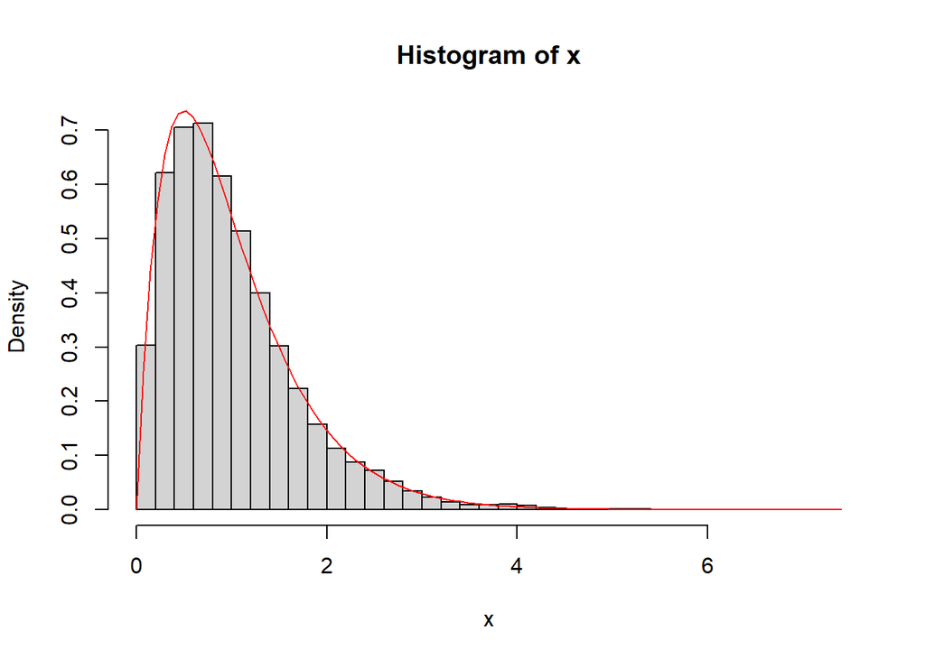

```r
n <- 10000
# God practice to fix a seed when you generate r.s., otherwise every time you compile you'll obtain different results
set.seed(1234)
x <- rgamma(n, alpha, theta)

# Plot the histogram
hist(x, prob = TRUE, nclass = 30)
curve(dgamma(x, alpha, theta), col = "red", add = TRUE)
```

Now we can compare

- Expected value (first moment) ${\rm E}(X)= \alpha/\lambda=1$ with the sample one $\bar x$= 1.0027774
- Variance (second central moment) ${\rm V}(X)= \alpha/\lambda^2=0.5$ with the sample one $\sigma^2$= 0.5051883

### Special case and related distribution

If you are interested in random variables relationship take a look to https://www.tandfonline.com/doi/abs/10.1198/000313008X270448. (in the Lab1 folder you can find the pdf)

We will verify

- $X \sim \mathcal{Exp}(\lambda)$ is given by setting to 1 the shape parameter of the gamma distribution

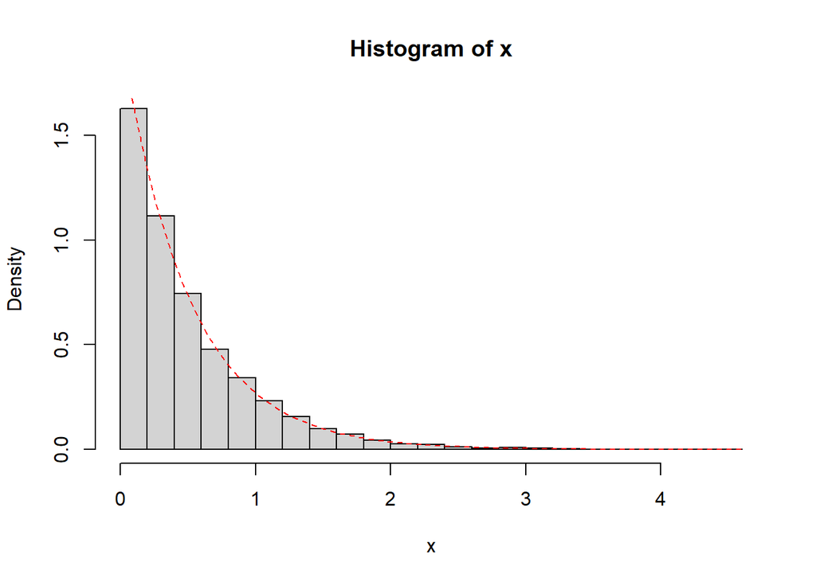

```r
alpha <- 1
x <- rexp(n, theta)
hist(x, prob = TRUE, nclass = 30)
curve(dgamma(x, alpha, theta), col = "red", lty = "dashed", add = TRUE)
```

- let $X$ and $Y$ two independent random variables distributed as $X \sim \mathcal{Gamma}(\alpha, \theta)$ and $Y \sim \mathcal{Gamma}(\beta, \theta)$, then $Z=\frac{X}{X+Y}$ is distributed as $Z \sim \mathcal{Beta}(\alpha, \beta)$ (I would suggest to try to obtain such relationship theoretically via transformation of random variables )

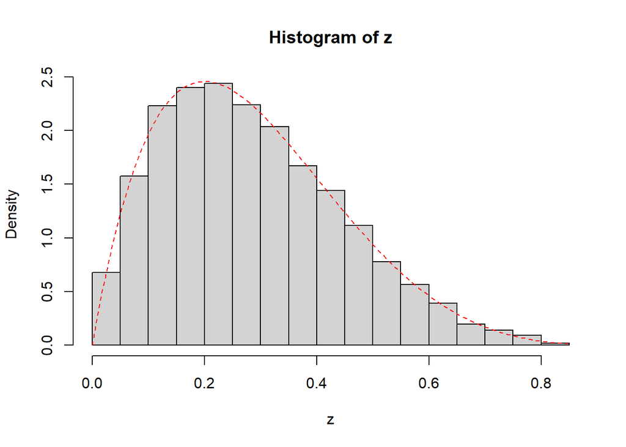

```r
alpha <- 2 #shape of X
beta <- 5 #shape of Y

theta <- 5 # common rate

x <- rgamma(n, alpha, theta)
y <- rgamma(n, beta, theta)

z <- x/(x+y)
hist(z, prob = TRUE, nclass = 30 )
curve(dbeta(x, alpha, beta), col = "red", lty = "dashed", add = TRUE)
```

## Negative Binomial

In the theory lecture you take into account the case where $X \sim \mathcal{NB}(p,r)$ models the number of trials needed to observe the $r$-th success (considering a Bernoulli experiment).

Here we consider the negative binomial used to model the number of failures before a prefixed number of successes ($r$) where the probability of success in each Bernoulli trial is $p$. ( considering a Bernoulli experiment)

The probability mass function of the negative binomial distribution (also Pascal distribution), $X \sim \mathcal{NB}(p,r)$, is stated as

$$P(X=x) = \binom{r+x-1}{r-1}p^r(1-p)^k, \quad \quad p \in (0,1), \quad r =1,2,\ldots , \quad x =0,1,2, \ldots$$
You could obtain the alternative formulation (see the slides) by taking $Y=X+r$, that is $Y \sim \mathcal{NB}(p,r)$, has pmf
$$P(Y = y) = \binom{y-1}{r-1}p^r(1-p)^{y-r}, \quad \quad p \in (0,1), \quad r =1,2, \ldots, \quad y = r,r+1, r+2, \ldots$$

### Special cases

The Negative binomial is related to:

- Geometric distribution: given a sequence of independent and identically distributed random variables, $X_1, \ldots, X_r$ from $\mathcal{Geo}(p)$, then $S_r=\sum_{i=1}^{r}{X_i} \sim \mathcal{NB}(p, r)$

```r
n <- 10000
r <- 5
p <- 0.7

set.seed(13)
x <- rnbinom(n, r, p)
y <- rep(0, n)

for(i in 1 : n){
 y[i] <- sum(rgeom(r, p))
}

ltx <- length(table(x))
lty <- length(table(y))


# Comparing the relative frequencies
relf <- matrix(0, 2, max(ltx, lty))
relf[1, 1 : ltx] <- round(table(x)/n, 3)
relf[2, 1 : lty] <- round(table(y)/n, 3)
colnames(relf) <- 0:(max(ltx, lty)-1)

relf
```

```
##          0     1     2     3     4     5     6     7     8     9    10 11 12 13
## [1,] 0.168 0.247 0.228 0.159 0.098 0.053 0.026 0.013 0.007 0.002 0.001  0  0  0
## [2,] 0.165 0.255 0.227 0.162 0.096 0.052 0.024 0.011 0.005 0.002 0.001  0  0  0
```

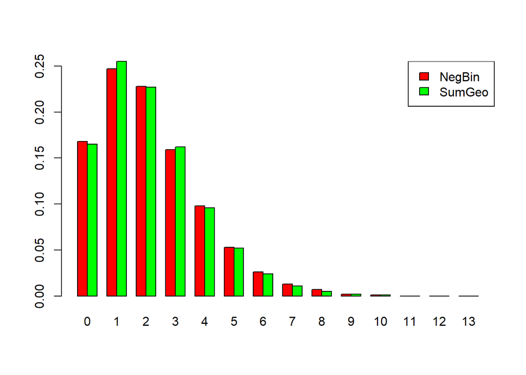

```r
# Comparison via adjacent barplot
barplot(relf, beside=TRUE,col=c("red", "green"))
legend("topright",
c("NegBin","SumGeo"),
fill = c("red","green")
)
```

- Poisson-Gamma mixture, that is a Poisson distribution $\mathcal{Poisson}(\lambda)$ where $\lambda \sim Gamma(\alpha, \sigma)$, with the shape parameter $\alpha = r$ and scale parameter $\sigma = \frac{1-p}{p}$

```r
lambda = rgamma(n, shape = r, rate = p/(1-p))
y = rpois(n, lambda = lambda)

ltx <- length(table(x))
lty <- length(table(y))

# Comparing the relative frequencies
relf <- matrix(0, 2, max(ltx, lty))
relf[1, 1 : ltx] <- round(table(x)/n, 3)
relf[2, 1 : lty] <- round(table(y)/n, 3)
colnames(relf) <- 0:(max(ltx, lty)-1)
relf
```

```
##          0     1     2     3     4     5     6     7     8     9    10 11 12 13
## [1,] 0.168 0.247 0.228 0.159 0.098 0.053 0.026 0.013 0.007 0.002 0.001  0  0  0
## [2,] 0.167 0.264 0.231 0.153 0.090 0.049 0.025 0.012 0.006 0.002 0.001  0  0  0
```

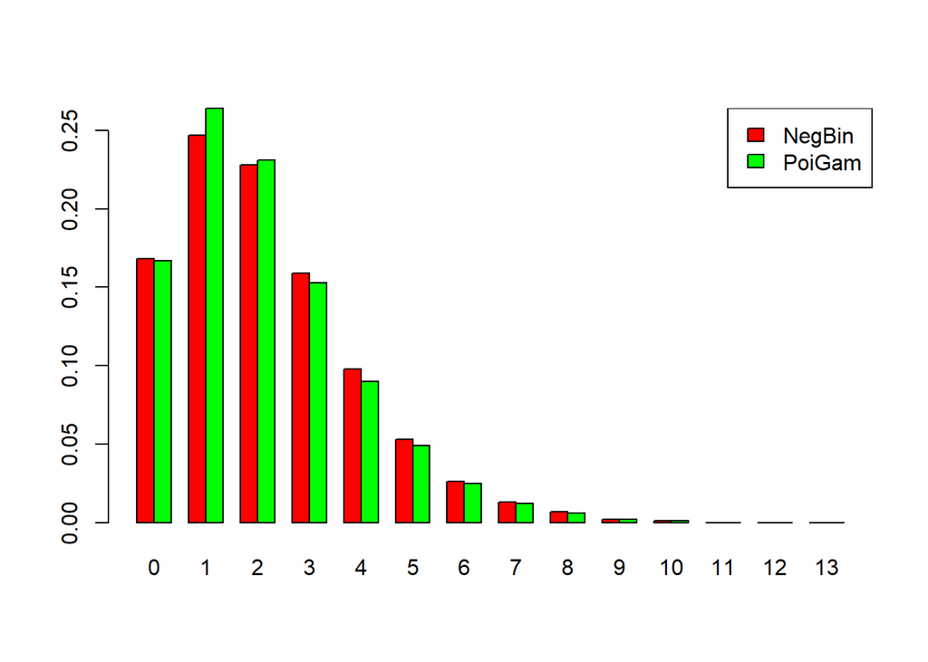

```r
# Comparison via adjacent barplot
barplot(relf, beside = TRUE, col = c("red", "green"))
legend("topright", c("NegBin","PoiGam"), fill = c("red","green"))
```

### Exercise

The geometric distribution could be used to model the number of failures before the first success (in a Bernoulli experiment). Then, let $X \sim Geo(p)$ the p.m.f. is given by
$$P(X=k) = p(1-p)^k , p \in (0,1), \quad k = 0, 1, 2, \ldots$$
(It could be used to model the time of the first success. In such a case, $Y=X+1$. ) By considering $p=0.3$,

- plot the probability mass function and the cumulative probability function
- compute $P(X = 3)$, $P(X\leq 1)$ and $P(X>2)$
- Compare the sample mean with the expected value ${\rm E}(X)=\frac{1-p}{p}$

Here the pmf and the cdf plots

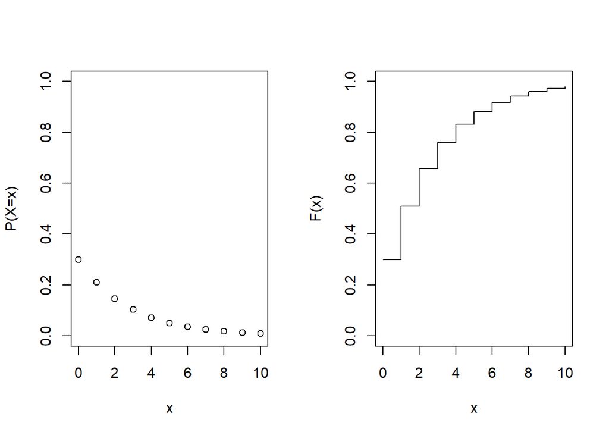

```r
p <- 0.3

par(mfrow = c(1,2)) #two plots on the same graph: 1 = nrow, 2=ncol
plot(0 : 10, dgeom(0 : 10, p), xlim = c(0, 10), ylim = c(0, 1), xlab = "x",ylab = "P(X=x)")
plot(0 : 10, pgeom(0 : 10, p), xlim = c(0, 10), ylim = c(0, 1), type = "s",xlab = "x", ylab = "F(x)")
```

```r
par(mfrow = c(1, 1))  # Return to the initial setting
```

Here we compute the probabilities

```r
# P(X=3)
dgeom(3, p)
```

```
## [1] 0.1029
```

```r
# P(X <= 1)
pgeom(1, p)
```

```
## [1] 0.51
```

```r
#Alternatively
#dgeom(0,p) + dgeom(1, p)

# P(X > 2)
pgeom(2, p, lower.tail = FALSE)
```

```
## [1] 0.343
```

```r
# Alternatively
#1 - dgeom(0, p) - dgeom(1, p) - dgeom(2,p)
```

Here we compare the sample mean with the expected value

```r
set.seed(1)
x<- rgeom(1000, p)

# Sample mean
mean(x)
```

```
## [1] 2.315
```

```r
# Expected value
(1-p)/p
```

```
## [1] 2.333333
```

# Monte Carlo simulation

*Simulation* is a well-known technique designed to approximate a process and to retrieve general results by assuming to observe the process several times. We rely on the so called **Monte Carlo** simulation, a wide class of simulation procedures based on sampling independent and identically distributed values from a process —precisely, from the underlying presumibly true probability distribution of the process— and computing numerical outputs. The steps of a Monte Carlo simulation are:

- generate $n$ independent and identically distributed values from a process;
- compute a summary for this sample, a statistic;
- repeat the steps above $R$ times and obtain a sample distribution for the statistic.

## Some relationships among probability distributions

Let $U_i\sim U(0,1)$, $i=1,\ldots,n$ be independent and identically distributed random variables (from a uniform continuous distribution).

We can verify that the random variable $X$ defined as:
$$X=-\frac{\log(U_1)}{\theta}$$
follows an exponential distribution with parameter $\theta$. (Fix $\theta = 2$)

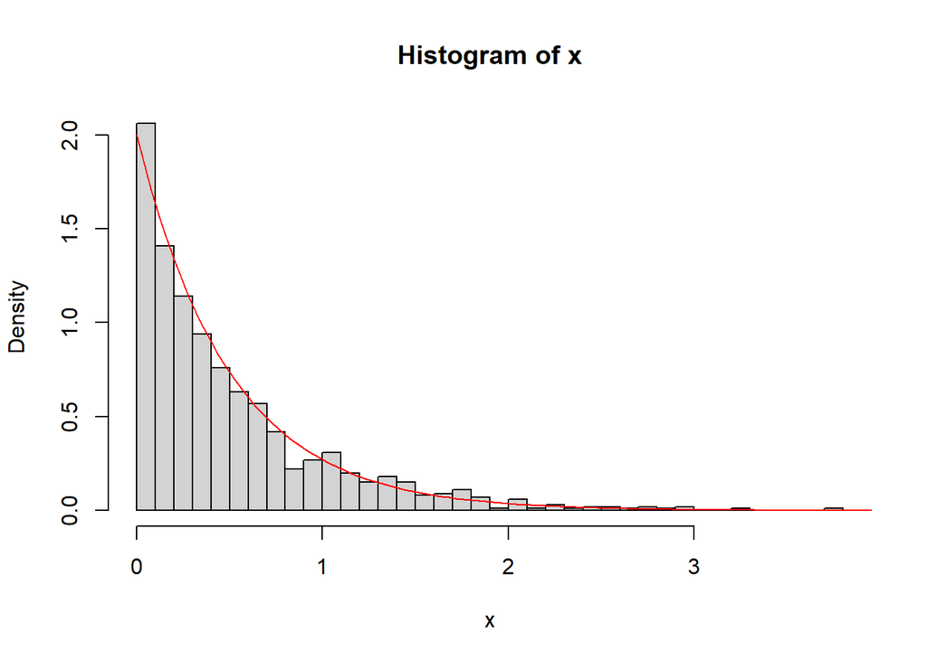

```r
R <- 1000
theta<- 2

x <- rep(0,R)
for(i in 1 : R) {
  u <- runif(1, 0, 1)
  x[i] <- -log(u)/theta
}

hist(x, prob = TRUE, breaks = 30)
curve(dexp(x, theta), from = 1e-16, to = 4, add = T, col = "red")
```

Now we verify that the random variable $Z=min\{X_1,X_2, \ldots, X_n\}$, where $X_i=-\log(U_i)/\theta$, follows an exponential distribution with parameter $n\theta$.

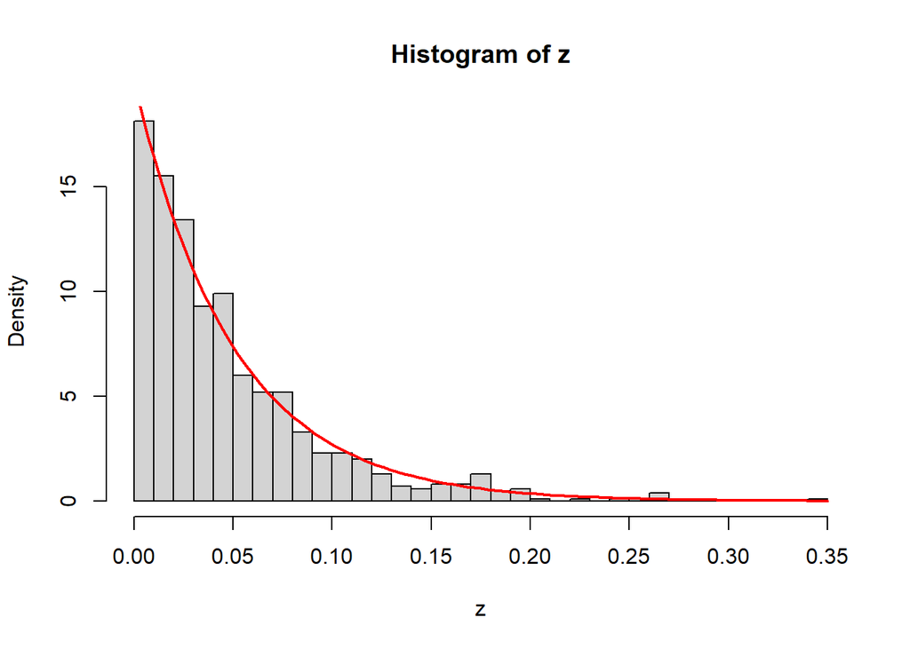

```r
z <- rep(0, R)
n <- 10
for (i in 1:R) {
  u <- runif(n, 0, 1)
  z[i] <- min(-log(u)/theta)
}

hist(z, prob = TRUE, breaks = 30)
curve(dexp(x, n * theta), add = T, lwd = 2, col = "red")
```

**Very simple exercise for you**

Verify that the distribution of the random variable $Y=\sum_{i=1}^{n} X_i$ follows a Gamma distribution with parameters shape=$n$ and rate=$\theta$.

## Normal and chi-square distribution

Let $x_1, x_2, \ldots, x_n$ a random sample simulated from $X\sim N(0,1)$ and $T_n=\sum_{i=1}^{n}X_i^2$. Using a Monte Carlo simulation study, verify that $T_n$ follows a chi-square distribution with n degrees of freedom. (Consider $n=10$)

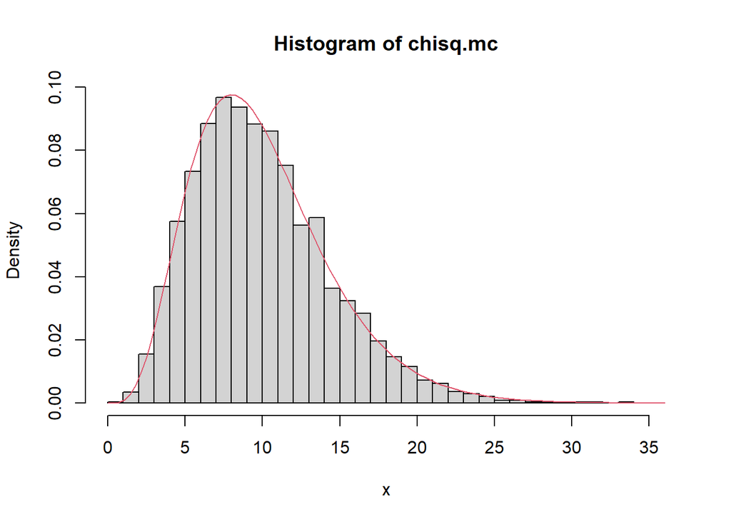

```r
n <- 10
R <- 10000
chisq.mc <- rep(0, R)
for (i in 1 : R){
  x <- rnorm(n = n, mean = 0, sd = 1)
  chisq.mc[i] <- sum(x^2)
 }

hist(chisq.mc, probability = TRUE, xlab = "x", breaks = 30)
curve(dchisq(x = x, df = n), add = TRUE, col = 2)
```

Compare the empirical cumulative distribution function with the cumulative distribution function.

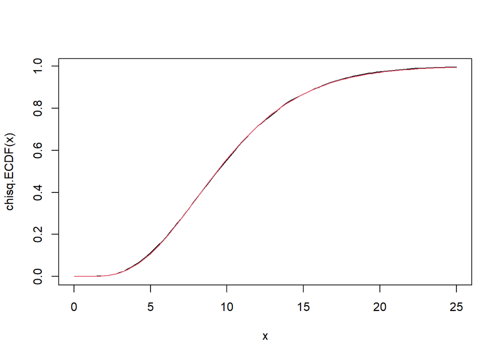

```r
chisq.ECDF <- ecdf(chisq.mc)
curve(chisq.ECDF(x), from = 0, to = 25, xlab = "x")
curve(pchisq(q = x, df = n), add = TRUE, col = 2)
```